# Intro to time series analysis

1 April 2025

## Topics for today

### Characteristics of time series (ts)

- What is a ts?
- Classifying ts
- Trends
- Seasonality (periodicity)

### Classical decomposition

## What is a time series?

### A set of observations taken sequentially in time

## What is a time series?

### A ts can be represented as a set

\[ \{ x_1,x_2,x_3,\dots,x_n \} \]

### For example,

\[ \{ 10,31,27,42,53,15 \} \]

[figure not shown]

## Classification of time series

### By some *index set*

Interval across real time; \(x(t)\)

- begin/end: \(t \in [1.1,2.5]\)

## Classification of time series

### By some *index set*

Discrete time; \(x_t\)

- Equally spaced: \(t = \{1,2,3,4,5\}\)
- Equally spaced w/ missing value: \(t = \{1,2,4,5,6\}\)
- Unequally spaced: \(t = \{2,3,4,6,9\}\)

## Classification of time series

### By the *underlying process*

Discrete (eg, total # of fish caught per trawl)

Continuous (eg, salinity, temperature)

## Classification of time series

### By the *number of values recorded*

Univariate/scalar (eg, total # of fish caught)

Multivariate/vector (eg, # of each spp of fish caught)

## Classification of time series

### By the *type of values recorded*

Integer (eg, # of fish in 5 min trawl = 2413)

Rational (eg, fraction of unclipped fish = 47/951)

Real (eg, fish mass = 10.2 g)

Complex (eg, cos(2π2.43) + *i* sin(2π2.43))

## Classification of time series

### We will focus on integers & real-values in discrete time

Univariate \((x_t)\)

Multivariate \(\begin{bmatrix} x_1 \\ x_2 \\ \vdots \\ x_n \end{bmatrix}_t\)

## Time series objects in R

Time series objects have a special designation in R: `ts`

```r
ts(data,
   start, end,
   frequency
   )
```

## Time series objects in R

Time series objects have a special designation in R: `ts`

```r
ts(data,
   start, end,
   frequency
   )
```

`data` should be a vector (univariate)

or a data frame or matrix (multivariate)

## Time series objects in R

Time series objects have a special designation in R: `ts`

```r
ts(data,
   start, end,
   frequency
   )
```

`start` and `end` give the first and last time indices

For monthly series, specify them as `c(year, month)`

## Time series objects in R

Time series objects have a special designation in R: `ts`

```r
ts(data,
   start, end,
   frequency
   )
```

`frequency` is the number of observations per unit time

For annual series, `frequency = 1`

For monthly series, `frequency = 12`

## Time series objects in R

Time series objects have a special designation in R: `ts`

```r
ts(data,
   start, end,
   deltat
   )
```

`deltat` is the fraction of the sampling period

For annual series, `deltat = 1`

For monthly series, `deltat = 1/12`

## Time series objects in R

```r
set.seed(507)

## annual data
dat_1 <- rnorm(30)
dat_yr <- ts(dat_1,
             start = 1991, end = 2020,
             frequency = 1)

## monthly data
dat_2 <- rnorm(30*12)
dat_mo <- ts(dat_2,
             start = c(1991, 1), end = c(2020, 12),
             frequency = 12)
```

## Plotting time series objects in R

There is a designated function for plotting `ts` objects: `plot.ts()`

```r
plot.ts(ts_object)
```

## Plotting time series objects in R

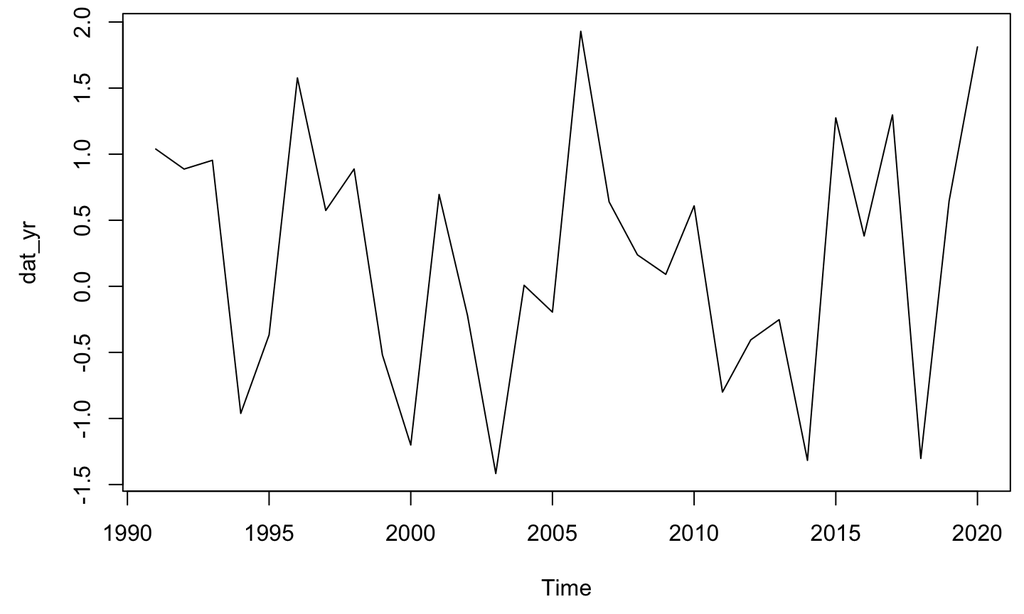

## Plotting time series objects in R

We can specify some additional arguments to `plot.ts`

```r
plot.ts(dat_yr,
        ylab = expression(italic(x[t])),
        las = 1, col = "blue", lwd = 2)
```

## Plotting time series objects in R

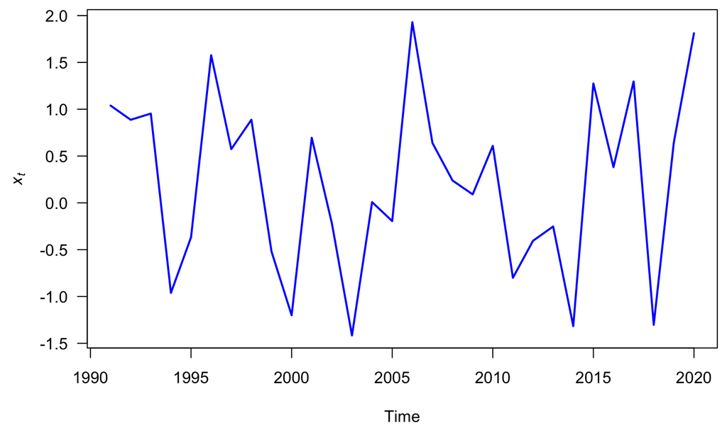

## Analysis of time series

## Statistical analyses of time series

Most statistical analyses are concerned with estimating properties of a population from a sample

For example, we use fish caught in a seine to infer the mean size of fish in a lake

## Statistical analyses of time series

Time series analysis, however, presents a different situation:

- Although we could vary the *length* of an observed time series, it is often impossible to make multiple observations at a *given* point in time

## Statistical analyses of time series

Time series analysis, however, presents a different situation:

- Although we could vary the *length* of an observed time series, it is often impossible to make multiple observations at a *given* point in time

For example, one can’t observe today’s closing price of Microsoft stock more than once

Thus, conventional statistical procedures, based on large sample estimates, are inappropriate

## Descriptions of time series

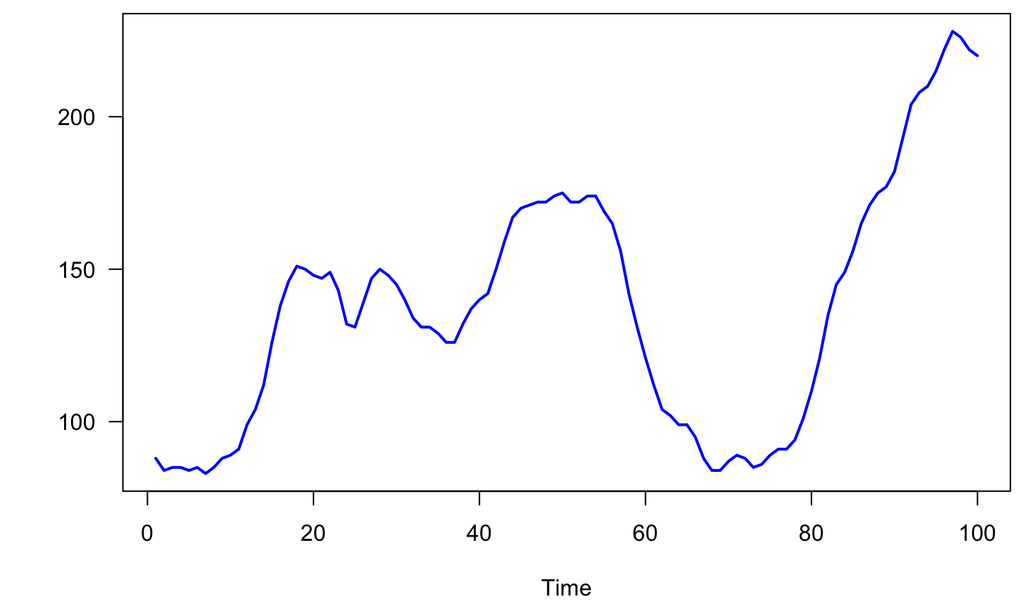

Number of users connected to the internet

## Descriptions of time series

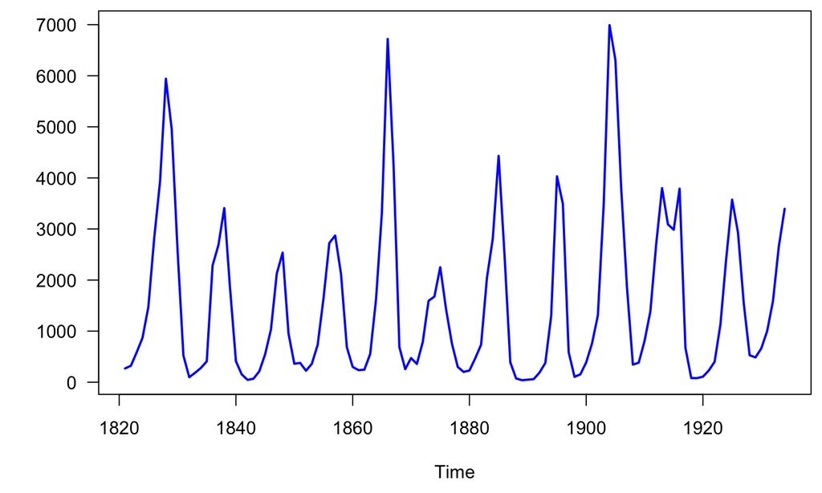

Number of lynx trapped in Canada from 1821-1934

## What is a time series model?

A *time series model* for \(\{x_t\}\) is a specification of the *joint distributions* of a sequence of *random variables* \(\{X_t\}\), of which \(\{x_t\}\) is thought to be a realization

## Joint distributions of random variables

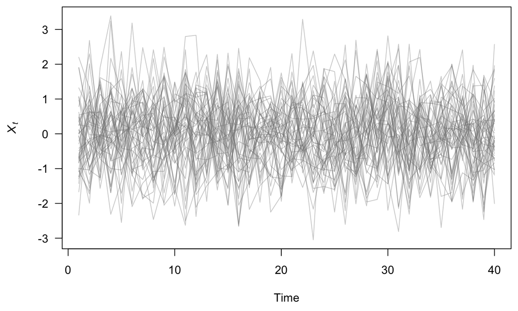

## We have one realization

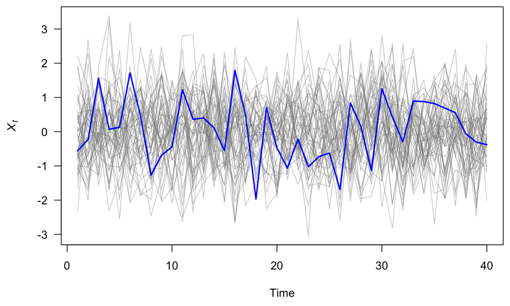

## Some simple time series models

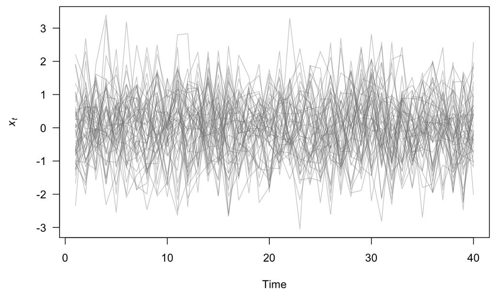

White noise: \(x_t \sim N(0,1)\)

## Some simple time series models

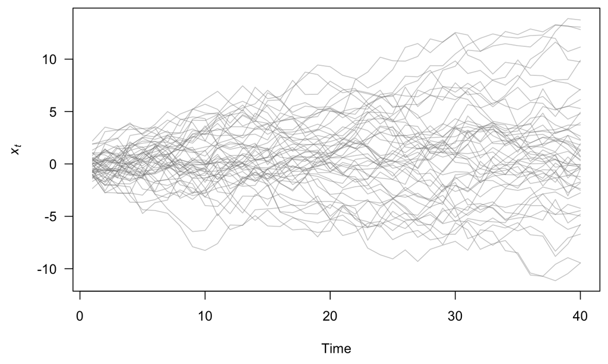

Random walk: \(x_t = x_{t-1} + w_t,~\text{with}~w_t \sim N(0,1)\)

## Classical decomposition

### Model time series \(\{x_t\}\) as a combination of

1. trend (\(m_t\))
2. seasonal component (\(s_t\))
3. remainder (\(e_t\))

\(x_t = m_t + s_t + e_t\)

## Classical decomposition

### 1. The trend (\(m_t\))

We need a way to extract the so-called *signal* from the *noise*

One common method is via “linear filters”

Linear filters can be thought of as “smoothing” the data

## Classical decomposition

### 1. The trend (\(m_t\))

Linear filters typically take the form

\[ \hat{m}_t = \sum_{i=-\infty}^{\infty} \lambda_i x_{t+1} \]

## Classical decomposition

### 1. The trend (\(m_t\))

For example, a moving average

\[ \hat{m}_t = \sum_{i=-a}^{a} \frac{1}{2a + 1} x_{t+i} \]

## Classical decomposition

### 1. The trend (\(m_t\))

For example, a moving average

\[ \hat{m}_t = \sum_{i=-a}^{a} \frac{1}{2a + 1} x_{t+i} \]

If \(a = 1\), then

\[ \hat{m}_t = \frac{1}{3}(x_{t-1} + x_t + x_{t+1}) \]

## Classical decomposition

### 1. The trend (\(m_t\))

For example, a moving average

\[ \hat{m}_t = \sum_{i=-a}^{a} \frac{1}{2a + 1} x_{t+i} \]

As \(a\) increases, the estimated trend becomes more smooth

## Example of linear filtering

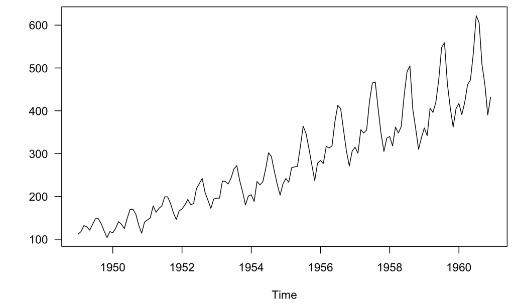

Monthly airline passengers from 1949-1960

## Example of linear filtering

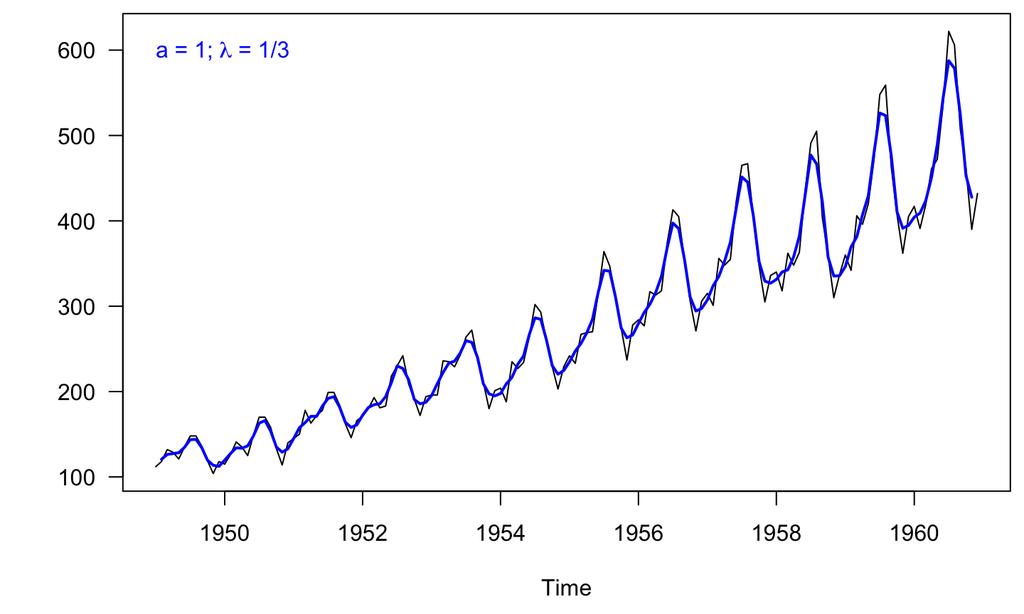

Monthly airline passengers from 1949-1960

## Example of linear filtering

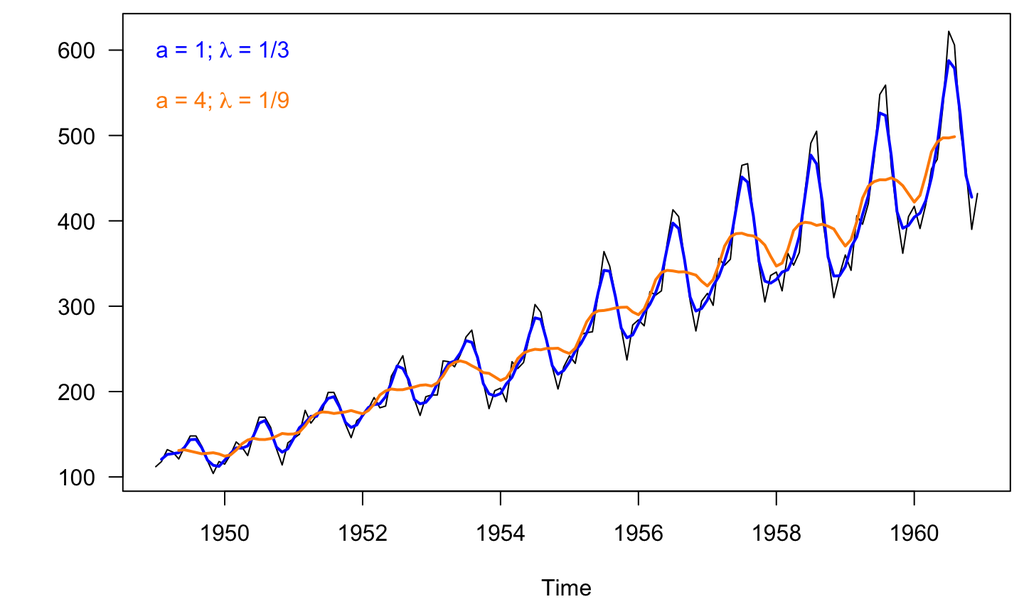

Monthly airline passengers from 1949-1960

## Example of linear filtering

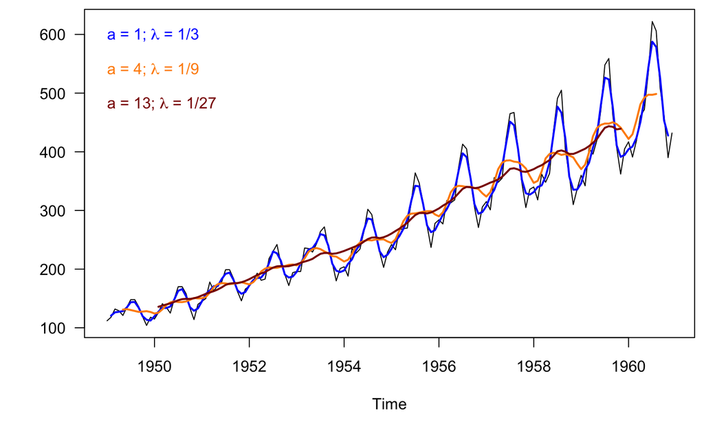

Monthly airline passengers from 1949-1960

## Classical decomposition

### 2. Seasonal effect (\(s_t\))

Once we have an estimate of the trend \(\hat{m}_t\), we can estimate \(\hat{s}_t\) simply by subtraction:

\[ \hat{s}_t = x_t - \hat{m}_t \]

## Classical decomposition

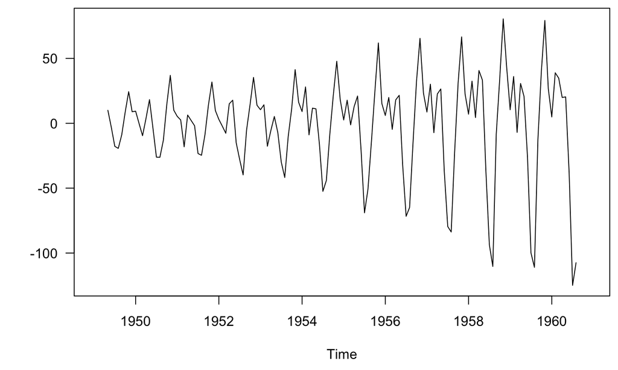

Seasonal effect (\(\hat{s}_t\)), assuming \(\lambda = 1/9\)

## Classical decomposition

### 2. Seasonal effect (\(s_t\))

But, \(\hat{s}_t\) really includes the remainder \(e_t\) as well

\[ \begin{align} \hat{s}_t &= x_t - \hat{m}_t \\ (s_t + e_t) &= x_t - m_t \end{align} \]

## Classical decomposition

### 2. Seasonal effect (\(s_t\))

So we need to estimate the *mean* seasonal effect as

\[ \hat{s}_{Jan} = \sum \frac{1}{(N/12)} \{s_1, s_{13}, s_{25}, \dots \} \\ \hat{s}_{Feb} = \sum \frac{1}{(N/12)} \{s_2, s_{14}, s_{26}, \dots \} \\ \vdots \\ \hat{s}_{Dec} = \sum \frac{1}{(N/12)} \{s_{12}, s_{24}, s_{36}, \dots \} \\ \]

## Mean seasonal effect (\(s_t\))

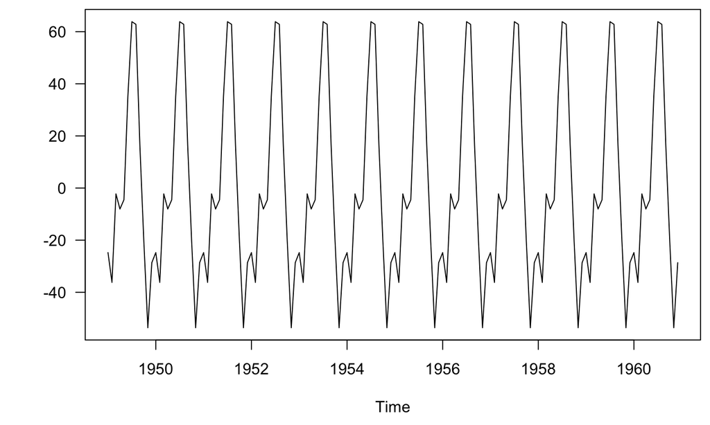

## Classical decomposition

### 3. Remainder (\(e_t\))

Now we can estimate \(e_t\) via subtraction:

\[ \hat{e}_t = x_t - \hat{m}_t - \hat{s}_t \]

## Remainder (\(e_t\))

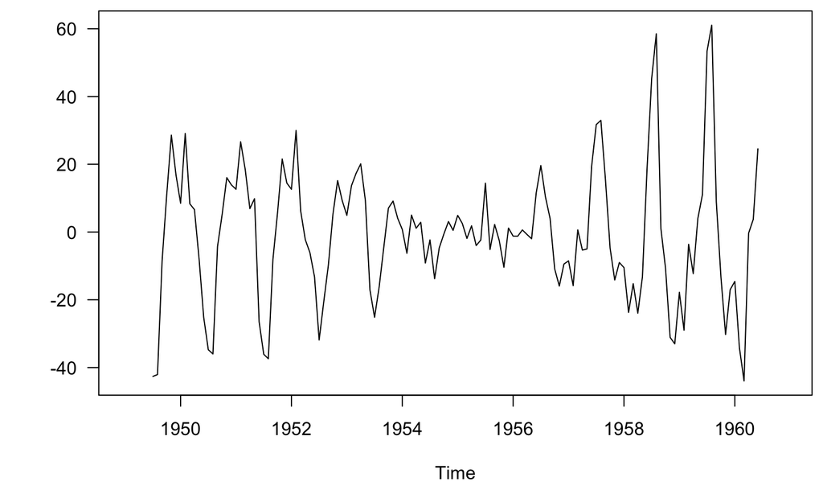

## Let’s try a different model

### With some other assumptions

1. Log-transform data
2. Linear trend

## Log-transformed data

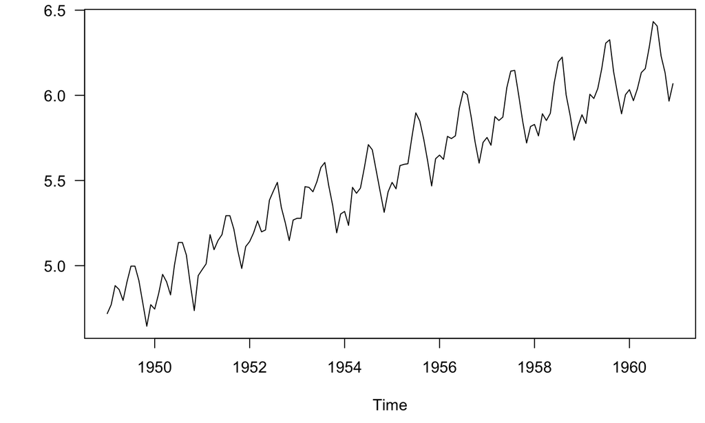

Monthly airline passengers from 1949-1960

## The trend (\(m_t\))

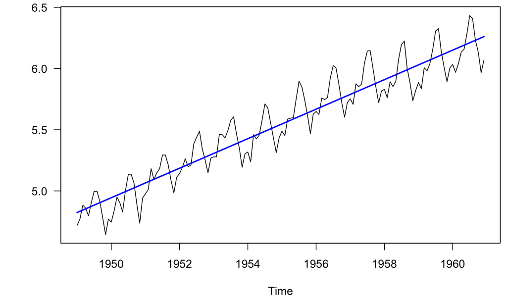

## Seasonal effect (\(s_t\)) with error (\(e_t\))

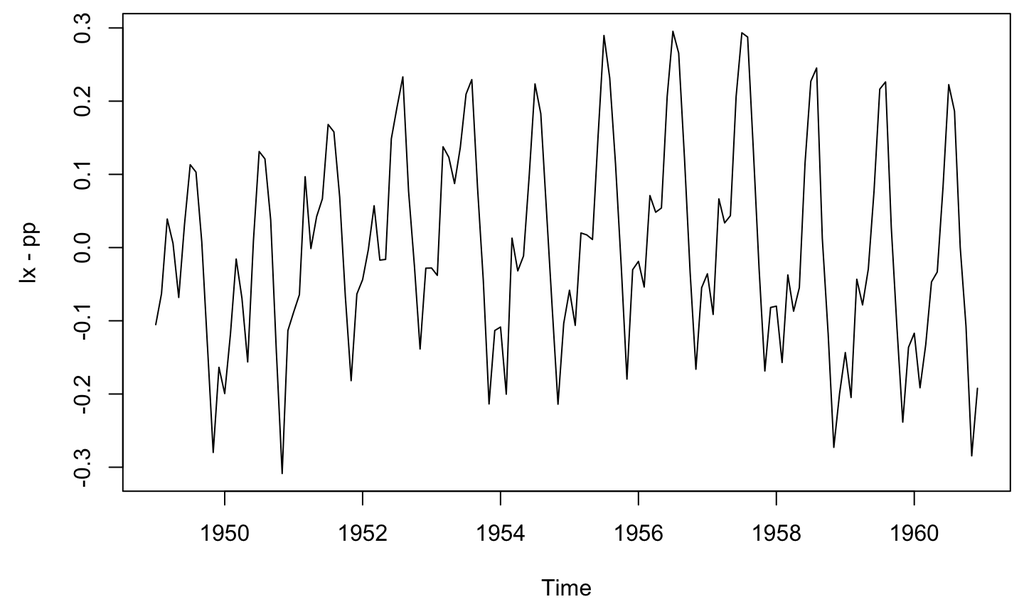

## Mean seasonal effect (\(s_t\))

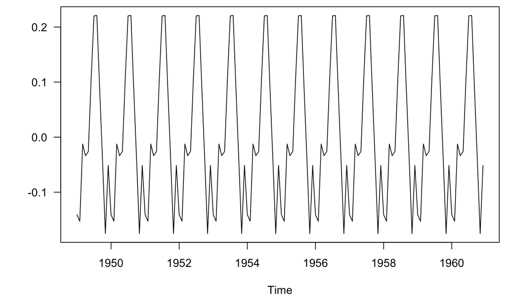

## Remainder (\(e_t\))

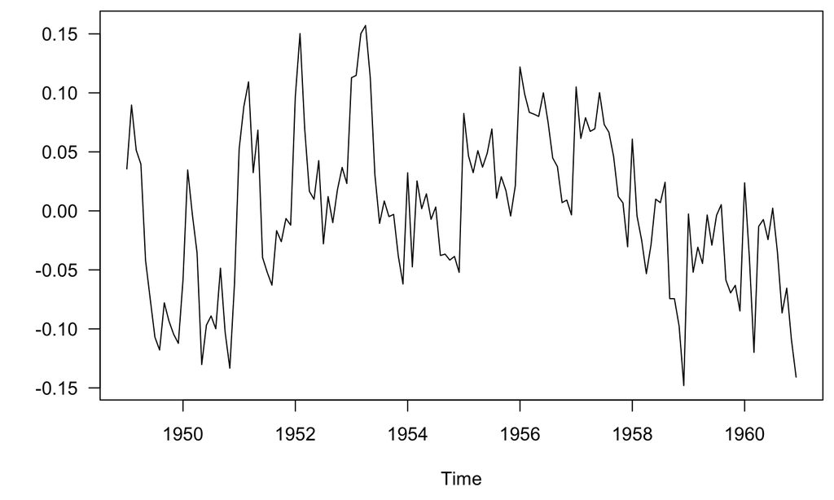

## Summary

### Today’s topics

### Characteristics of time series (ts)

- What is a ts?
- Classifying ts
- Trends
- Seasonality (periodicity)